# Constraint-based modeling of metabolically engineered *S.elongatus*

## Introduction to flux balance analysis

### Representing metabolic networks

A genome scale metabolic network is a graph representing all possible reactions happening in a given organism, along with the genes encoding the enzymes carrying out these reactions. In our study, we utilize a previously published metabolic model of Synechococcus elongatus, which was constructed using established methodologies for genome-scale metabolic reconstruction. This constraint-based model represents the complete set of biochemical reactions occurring in the cell and is mathematically formulated as a stoichiometric matrix, where each entry corresponds to the stoichiometric coefficient of a given metabolite in a specific reaction. Metabolic networks are usually reconstructed from structural and functional genome annotations.

### Defining constraints

The model is subject to two main types of constraints, equilibrium and flux bounds.

- Steady-state assumption: For each metabolite, the total rate of production must equal the total rate of consumption.
- Flux bounds: Each reaction can operate only within specified upper and lower bounds, representing physiological relevant or experimentally determined limits.

More constraints can be defines. For example, genetic perturbations, such as gene knockouts, can be simulated in the model by setting the flux through associated reactions to zero. This allows for in silico prediction of gene essentiality and the impact of genetic modifications on metabolic performance.

### Questions to be explored

Possible questions to explore:

- What is the effect of introducing the genes for the 3HPP into the S. elongatus strain?
- Can a gene essentiality analysis predict which genes are critical for survival or optimal growth?
- Which genes can be deleted without significantly impairing growth or metabolism, and might therefore be targets for strain optimization?

## Metabolic modeling using COBRApy

COBRApy is a Python library for constraint-based modeling of biological networks, commonly used in genome-scale metabolic modeling.

### Imports of COBRApy packages

The following code snippet loads essential components from the COBRApy package, Run the following cell to load the required COBRApy modules. This step is necessary before you can execute any of the code below.

```python
import cobra
from cobra.io import load_model
from cobra.util.solver import linear_reaction_coefficients
from cobra import Model, Reaction, Metabolite
from cobra.flux_analysis import find_blocked_reactions, flux_variability_analysis
from cobra.flux_analysis import single_reaction_deletion
from cobra.flux_analysis import single_gene_deletion
```

### Loading and inspection of the genome-scale metabolic network

First, we load the genome scale metabolic network of the strain from the COBRApy's built-in library. Here, we loaded the metabolic model iJB785 of the strain *S.elongatus* PCC7942, published by Broddrick et al, in 2016. Note that the genome-scale metabolic models for the strain *S.elongatus* PCC11801 and PCC11802, haven't been published yet.

```python
model_PCC7942 = load_model("iJB785") # loading the metabolic network of S.elongatus PCC7942
```

We can check the number of reactions, metabolites and genes included in the network.

```python
print(f'There are {len(model_PCC7942.reactions)} reactions in the genome scale metabolic model.')
print(f'There are {len(model_PCC7942.metabolites)} metabolites in the genome scale metabolic model.')
print(f'There are {len(model_PCC7942.genes)} genes in the genome scale metabolic model.')
```

```
There are 849 reactions in the genome scale metabolic model.
There are 768 metabolites in the genome scale metabolic model.
There are 785 genes in the genome scale metabolic model.
```

We can also visualize that the default objective function encoded in the model is the biomass production. This is shown by the coefficient for this reaction set to 1 while all others are set to 0. This can of course be change if we want to maximize something else than the growth of the strain.

```python
linear_reaction_coefficients(model_PCC7942) # This returns the default coefficients
```

```
{<Reaction BIOMASS__1 at 0x204df0ff110>: 1.0}
```

The biomass reaction is one of the most critical reactions in genome-scale metabolic models as it represents the overall process of cellular growth. It does not actually corresponds to a biochemical reaction happening in the cell. Rather, it summarizes all the reactions that contribute to the production of biomass components necessary for growth, such as proteins, lipids, nucleotides, and other macromolecules, as well as the steochiometry of each of these components.

Experimental data usually help refine the biomass reaction by providing emprirical estimates of the actual composition of biomass in the organism. This may involve determining the stoichiometric coefficients of the biomass components, such as the number of amino acids making up proteins or the number of lipids making up the membrane.

We can print the informations related to the biomass reaction stored in the model, to see the stoechiometry and components making up this reaction, as well as its flux lower and upper bounds.

```python
model_PCC7942.reactions.get_by_id('BIOMASS__1')
```

| **Reaction identifier** | BIOMASS__1 |
| --- | --- |
| **Name** | Biomass objective function |
| **Memory address** | 0x204df0ff110 |
| **Stoichiometry** | 30.0 atp_c + 0.0977 bm_carbs_c + 0.00119 bm_cofactors_c + 0.0795 bm_cw_c + 0.0073 bm_dna_c + 0.159 bm_memlip_c + 0.0197 bm_pigm_c + 0.5112 bm_pro_c + 0.1136 bm_rna_c + 30.0 h2o_c --> 30.0 adp_c +... 3… |
| **GPR** |  |
| **Lower bound** | 0.0 |
| **Upper bound** | 2.0 |

We can also check what is the default culture media set for the metabolic network. In such network, the culture media is represented by import reactions, with specific boundaries. A change in media can be represented by changing the boundary of a given metabolite.

```python
model_PCC7942.medium # Check exchange reactions representing the culture media
```

```
{'EX_hco3_e': 1.99,
 'EX_mn2_e': 0.0009,
 'EX_mg2_e': 0.03,
 'EX_ca2_e': 0.024,
 'EX_nh4_e': 0.0031,
 'EX_cu2_e': 3e-05,
 'EX_k_e': 0.046,
 'EX_h2o_e': 100.0,
 'EX_o2_e': 100.0,
 'EX_co2_e': 1.99,
 'EX_leu__L_e': 1000.0,
 'EX_cobalt2_e': 1.7e-05,
 'EX_no3_e': 1.76,
 'EX_zn2_e': 7.7e-05,
 'EX_fe3_e': 0.001,
 'EX_so4_e': 0.03,
 'EX_mobd_e': 0.00016,
 'EX_na1_e': 1.79854,
 'EX_h_e': 100.0,
 'EX_photon410_e': 1000.0,
 'EX_photon430_e': 1000.0,
 'EX_photon450_e': 1000.0,
 'EX_photon470_e': 1000.0,
 'EX_photon490_e': 1000.0,
 'EX_photon510_e': 1000.0,
 'EX_photon530_e': 1000.0,
 'EX_photon550_e': 1000.0,
 'EX_photon570_e': 1000.0,
 'EX_photon590_e': 1000.0,
 'EX_photon610_e': 1000.0,
 'EX_photon630_e': 1000.0,
 'EX_photon650_e': 1000.0,
 'EX_photon670_e': 1000.0,
 'EX_photon690_e': 1000.0,
 'EX_pi_e': 0.023}
```

### Running flux balance analysis

We are now all set to run our flux balance analysis. Before making any addition or deletion in the model, we can perform a flux balance analysis (FBA) with the growth as an objective function, to see what the maximum biomass production of the strain in its current state and the way the metabolic fluxes are shared between all metabolic pathways. By default, the objective function is the maximization of the growth of the cell, represented by the reaction of biomass production. The objective function is represented as coefficients, with 1 for the reaction that will be maximized by FBA and 0 for the reactions that are not maximized. Consequently, as the default value the coefficient of the biomass reaction is 1 and the coefficient for all other reactions are set to 0.

```python
solution_WT = model_PCC7942.optimize()
print(f"Status: {solution_WT.status}") # Indicates whether solutions were found
print(f"Biomass production: {solution_WT.objective_value:.5f}")
```

```
Status: optimal
Biomass production: 0.05390
```

```python
solution_WT.fluxes["VPAMTr"] # Change this
```

```
0.27703225450409097
```

The summary() function allows us to access the flux of each metabolites that are uptaken and secreted.

```python
model_PCC7942.summary()
```

Objective

1.0 BIOMASS__1 = 0.053902514144384656

Uptake

| Metabolite | Reaction | Flux | C-Number | C-Flux |
| --- | --- | --- | --- | --- |
| co2_e | EX_co2_e | 1.331 | 1 | 56.79% |
| fe3_e | EX_fe3_e | 8.635E-05 | 0 | 0.00% |
| h2o_e | EX_h2o_e | 0.6123 | 0 | 0.00% |
| h_e | EX_h_e | 1.27 | 0 | 0.00% |
| hco3_e | EX_hco3_e | 0.8429 | 1 | 35.95% |
| leu__L_e | EX_leu__L_e | 0.02837 | 6 | 7.26% |
| mg2_e | EX_mg2_e | 0.0006043 | 0 | 0.00% |
| nh4_e | EX_nh4_e | 0.0031 | 0 | 0.00% |
| no3_e | EX_no3_e | 0.4029 | 0 | 0.00% |
| photon430_e | EX_photon430_e | 0.0006043 | 0 | 0.00% |
| photon650_e | EX_photon650_e | 11.7 | 0 | 0.00% |
| photon690_e | EX_photon690_e | 18.2 | 0 | 0.00% |
| pi_e | EX_pi_e | 0.023 | 0 | 0.00% |
| so4_e | EX_so4_e | 0.008394 | 0 | 0.00% |
| amylose_c | SK_amylose_c | 0.02769 | 0 | 0.00% |

Secretion

| Metabolite | Reaction | Flux | C-Number | C-Flux |
| --- | --- | --- | --- | --- |
| 5drib_c | DM_5drib_c | -5.6E-06 | 5 | 26.10% |
| amob_c | DM_amob_c | -1.411E-06 | 15 | 19.73% |
| co_c | DM_co_c | -5.701E-05 | 1 | 53.14% |
| dialurate_c | DM_dialurate_c | -2.758E-07 | 4 | 1.03% |
| pho_loss_c | DM_pho_loss_c | -0.5849 | 0 | 0.00% |
| o2_e | EX_o2_e | -3.151 | 0 | 0.00% |

We can then focus on one metabolite of interest and see which are the reactions producting and consuming it. For example, here are the reaction producing and consuming pyruvate, as well as the flux through these reactions.

```python
model_PCC7942.metabolites.pyr_c.summary()
```

pyr_c

C3H3O3

Producing Reactions

| Percent | Flux | Reaction | Definition |
| --- | --- | --- | --- |
| 0.00% | 4.112E-06 | ADCL | 4adcho_c --> 4abz_c + h_c + pyr_c |
| 0.99% | 0.003852 | ANS2 | chor_c + nh4_c --> anth_c + h2o_c + h_c + pyr_c |
| 0.00% | 9.621E-07 | CHRPL | chor_c --> 4hbz_c + pyr_c |
| 8.20% | 0.03202 | ME2 | mal__L_c + nadp_c <=> co2_c + nadph_c + pyr_c |
| 19.86% | 0.07754 | PYK | adp_c + h_c + pep_c --> atp_c + pyr_c |
| 0.00% | 1.084E-06 | SHCHCS3 | 2sephchc_c --> 2shchc_c + pyr_c |
| 70.95% | 0.277 | VPAMTr | 3mob_c + ala__L_c --> pyr_c + val__L_c |

Consuming Reactions

| Percent | Flux | Reaction | Definition |
| --- | --- | --- | --- |
| 8.29% | -0.03237 | ACLSa | h_c + pyr_c + thmpp_c --> 2ahethmpp_c + co2_c |
| 4.29% | -0.01676 | ACLSb | 2ahethmpp_c + pyr_c --> alac__S_c + thmpp_c |
| 78.26% | -0.3055 | ALAD_L | ala__L_c + h2o_c + nad_c <=> h_c + nadh_c + nh4_c + pyr_c |
| 4.00% | -0.01561 | CITMS | accoa_c + h2o_c + pyr_c --> citm_c + coa_c + h_c |
| 1.86% | -0.007277 | DXPS | g3p_c + h_c + pyr_c --> co2_c + dxyl5p_c |
| 3.30% | -0.01288 | H4THDPS | aspsa_c + pyr_c --> 4hthdp_c + h2o_c + h_c |

### Visualizing flux balance analysis fluxes results

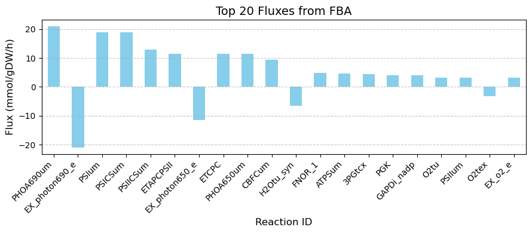

```python
import matplotlib.pyplot as plt
import pandas as pd

# Get top 20 fluxes by absolute value
top_fluxes = solution_FBA_WT.fluxes.abs().sort_values(ascending=False).head(20)

# Keep original signs for plotting
top_fluxes_signed = solution_FBA_WT.fluxes[top_fluxes.index]

# Create the bar plot
plt.figure(figsize=(9,4))
top_fluxes_signed.plot(kind='bar', color='skyblue')
plt.ylabel("Flux (mmol/gDW/h)", fontsize=12)
plt.xlabel("Reaction ID", fontsize=12)
plt.title("Top 20 Fluxes from FBA", fontsize=14)
plt.xticks(rotation=45, ha="right")
plt.grid(axis='y', linestyle='--', alpha=0.7)
plt.tight_layout()
plt.show()
```

### Adding the 3HPP cycle to the metabolic network of the strain

We are now going to add the enzymes of the 3HPP cycle to the original genome-scale metabolic network of *S.elongatus* PCC7942. First, we load the model (under a a different name than the WT model).

```python
model_PCC7942_with_gene_addition = load_model("iJB785")
```

We create a function that checks whether a metabolite already exists in a model, and creates it if it doesn't exist.

```python
def retrieve_or_create_metabolite(model_PCC7942_with_gene_addition, met_id, name, compartment="c"):
    try:
        return model_PCC7942_with_gene_addition.metabolites.get_by_id(met_id)
    except KeyError:
        m = Metabolite(id=met_id, name=name, compartment=compartment)
        model_PCC7942_with_gene_addition.add_metabolites([m])
        return m
```

#### Adding the Acetyl-CoA carboxylase

There is no need to add this enzyme as it already exists in the strain. We can see by looking at the GPR that this reaction requires 4 genes to be carried out.

```python
model_PCC7942_with_gene_addition.reactions.get_by_id('ACCOAC')
```

| **Reaction identifier** | ACCOAC |
| --- | --- |
| **Name** | Acetyl-CoA carboxylase |
| **Memory address** | 0x204f5ce26c0 |
| **Stoichiometry** | accoa_c + atp_c + hco3_c --> adp_c + h_c + malcoa_c + pi_c Acetyl-CoA + ATP C10H12N5O13P3 + Bicarbonate --> ADP C10H12N5O10P2 + H+ + Malonyl CoA C24H33N7O19P3S + Phosphate |
| **GPR** | SYNPCC7942_RS07060 and SYNPCC7942_RS08145 and SYNPCC7942_RS09925 and SYNPCC7942_RS13030 |
| **Lower bound** | 0.0 |
| **Upper bound** | 1000.0 |

### Adding the malonyl-CoA reductase/3-hydroxypropionate dehydrogenase (MCR)

```python
# We retrieve or create the substrate and product metabolites of the reaction catalyzed by this enzyme
msa_c = retrieve_or_create_metabolite(model_PCC7942_with_gene_addition, "msa_c", "Malonate semialdehyde")
hp3_c = retrieve_or_create_metabolite(model_PCC7942_with_gene_addition, "hp3_c", "3-Hydroxypropionate") # Made a change here: 3hp_c to hp3c

# Reaction 1: Malonyl-CoA → Malonate semialdehyde

# We create the reaction
mcr1 = Reaction("MCR1")
mcr1.name = "Malonyl-CoA reductase (step 1)"
mcr1.lower_bound = 0.0   # irreversible
mcr1.upper_bound = 1000.0

# We add the metabolites to the reaction by defining their stoechiometric coefficients
mcr1.add_metabolites({
    model_PCC7942_with_gene_addition.metabolites.malcoa_c: -1.0,
    model_PCC7942_with_gene_addition.metabolites.nadph_c: -1.0,
    model_PCC7942_with_gene_addition.metabolites.nadp_c:  1.0,
    msa_c: 1.0,
    model_PCC7942_with_gene_addition.metabolites.coa_c: 1.0
})

# Reaction 2: Malonate semialdehyde → 3-HP

# We create the reaction
mcr2 = Reaction("MCR2")
mcr2.name = "3-hydroxypropionate dehydrogenase (step 2)"
mcr2.lower_bound = 0.0
mcr2.upper_bound = 1000.0

# We add the metabolites to the reaction by defining their stoechiometric coefficients
mcr2.add_metabolites({
    msa_c: -1.0,
    model_PCC7942_with_gene_addition.metabolites.nadph_c: -1.0,
    model_PCC7942_with_gene_addition.metabolites.nadp_c:  1.0,
    hp3_c: 1.0
})

# We add these reactions to the model
model_PCC7942_with_gene_addition.add_reactions([mcr1, mcr2])
```

## Adding the propionyl-CoA synthase (PCS)

```python
# We retrieve or create the substrate and product metabolites of the reaction catalyzed by this enzyme
hp3_c = retrieve_or_create_metabolite(model_PCC7942_with_gene_addition, "hp3_c", "3-Hydroxypropionate")
coa_c = retrieve_or_create_metabolite(model_PCC7942_with_gene_addition, "coa_c",    "Coenzyme A")
atp_c = retrieve_or_create_metabolite(model_PCC7942_with_gene_addition, "atp_c",    "ATP")
amp_c = retrieve_or_create_metabolite(model_PCC7942_with_gene_addition, "amp_c",    "AMP")
ppi_c = retrieve_or_create_metabolite(model_PCC7942_with_gene_addition, "ppi_c",    "Diphosphate (PPi)")
h2o_c = retrieve_or_create_metabolite(model_PCC7942_with_gene_addition, "h2o_c",    "H2O")
h_c = retrieve_or_create_metabolite(model_PCC7942_with_gene_addition, "h_c",      "H+")
nadph_c = retrieve_or_create_metabolite(model_PCC7942_with_gene_addition, "nadph_c",  "NADPH")
nadp_c = retrieve_or_create_metabolite(model_PCC7942_with_gene_addition, "nadp_c",   "NADP+")
hp3coa_c = retrieve_or_create_metabolite(model_PCC7942_with_gene_addition, "hp3coa_c", "3-Hydroxypropionyl-CoA")
acrylcoa_c = retrieve_or_create_metabolite(model_PCC7942_with_gene_addition, "acrylcoa_c", "Acryloyl-CoA")
ppcoa_c = retrieve_or_create_metabolite(model_PCC7942_with_gene_addition, "ppcoa_c",  "Propionyl-CoA")


# Reaction 1: 3-HP + CoA + ATP → 3-HP-CoA + AMP + PPi (irreversible)

# We create the reaction
pcs1 = Reaction("PCS1")
pcs1.name = "Propionyl-CoA synthase (ligase: 3-HP → 3-HP-CoA)"
pcs1.lower_bound = 0.0
pcs1.upper_bound = 1000.0

# We add the metabolites to the reaction by defining their stoechiometric coefficients
pcs1.add_metabolites({
    hp3_c:   -1.0,
    coa_c:   -1.0,
    atp_c:   -1.0,
    hp3coa_c: 1.0,
    amp_c:    1.0,
    ppi_c:    1.0
})

# Reaction 2: 3-HP-CoA → Acryloyl-CoA + H2O (irreversible dehydration)

# We create the reaction
pcs2 = Reaction("PCS2")
pcs2.name = "Propionyl-CoA synthase (dehydratase: 3-HP-CoA → Acryloyl-CoA)"
pcs2.lower_bound = 0.0
pcs2.upper_bound = 1000.0

# We add the metabolites to the reaction by defining their stoechiometric coefficients
pcs2.add_metabolites({
    hp3coa_c:  -1.0,
    acrylcoa_c: 1.0,
    h2o_c:      1.0
})

# Reaction 3: Acryloyl-CoA + NADPH + H+ → Propionyl-CoA + NADP+ (irreversible)

# We create the reaction
pcs3 = Reaction("PCS3")
pcs3.name = "Propionyl-CoA synthase (reductase: Acryloyl-CoA → Propionyl-CoA)"
pcs3.lower_bound = 0.0
pcs3.upper_bound = 1000.0

# We add the metabolites to the reaction by defining their stoechiometric coefficients
pcs3.add_metabolites({
    acrylcoa_c: -1.0,
    nadph_c:    -1.0,
    h_c:        -1.0,
    ppcoa_c:     1.0,
    nadp_c:      1.0
})

# We add these reactions to the model
model_PCC7942_with_gene_addition.add_reactions([pcs1, pcs2, pcs3])
```

## Adding the malyl-CoA lyase

```python
# We retrieve or create the substrate and product metabolites of the reaction catalyzed by this enzyme
ppcoa_c = retrieve_or_create_metabolite(model_PCC7942_with_gene_addition, "ppcoa_c",   "Propionyl-CoA")
glx_c = retrieve_or_create_metabolite(model_PCC7942_with_gene_addition, "glx_c",   "Glyoxylate")
mmcoa_c = retrieve_or_create_metabolite(model_PCC7942_with_gene_addition, "mmcoa_c",   "beta-Methylmalyl-CoA")
citmlcoa_c = retrieve_or_create_metabolite(model_PCC7942_with_gene_addition, "citmlcoa_c", "Citramalyl-CoA")
malylcoa_c = retrieve_or_create_metabolite(model_PCC7942_with_gene_addition, "malylcoa_c", "Malyl-CoA")
pyr_c = retrieve_or_create_metabolite(model_PCC7942_with_gene_addition, "pyr_c",     "Pyruvate")
accoa_c = retrieve_or_create_metabolite(model_PCC7942_with_gene_addition, "accoa_c",   "Acetyl-CoA")

# Reaction 1: Propionyl-CoA + Glyoxylate → beta-Methylmalyl-CoA

# We create the reaction
mcl1 = Reaction("MCL1")
mcl1.name = "Malyl-CoA lyase (condensation: Propionyl-CoA + Glyoxylate)"
mcl1.lower_bound = 0.0
mcl1.upper_bound = 1000.0

# We add the metabolites to the reaction by defining their stoechiometric coefficients
mcl1.add_metabolites({
    ppcoa_c: -1.0,
    glx_c: -1.0,
    mmcoa_c: 1.0
})

# Reaction 2: Citramalyl-CoA → Pyruvate + Acetyl-CoA

# We create the reaction
mcl2 = Reaction("MCL2")
mcl2.name = "Malyl-CoA lyase (cleavage: Citramalyl-CoA)"
mcl2.lower_bound = 0.0
mcl2.upper_bound = 1000.0

# We add the metabolites to the reaction by defining their stoechiometric coefficients
mcl2.add_metabolites({
    citmlcoa_c: -1.0,
    pyr_c:      1.0,
    accoa_c:    1.0
})

# Reaction 3: Malyl-CoA → Acetyl-CoA + Glyoxylate

# We create the reaction
mcl3 = Reaction("MCL3")
mcl3.name = "Malyl-CoA lyase (cleavage: Malyl-CoA)"
mcl3.lower_bound = 0.0
mcl3.upper_bound = 1000.0

# We add the metabolites to the reaction by defining their stoechiometric coefficients
mcl3.add_metabolites({
    malylcoa_c: -1.0,
    accoa_c:    1.0,
    glx_c:    1.0
})

# We add these reactions to the model
model_PCC7942_with_gene_addition.add_reactions([mcl1, mcl2, mcl3])
for r in (mcl1, mcl2, mcl3):
    r.gene_reaction_rule = "Caur_0174"
    r.annotation["kegg.gene"] = "cau:Caur_0174"
```

## Adding the b-methylmalyl-CoA dehydratase

```python
# We retrieve or create the substrate and product metabolites of the reaction catalyzed by this enzyme
mmcoa_c = retrieve_or_create_metabolite(model_PCC7942_with_gene_addition, "mmcoa_c",   "beta-Methylmalyl-CoA")
mesacoac_c = retrieve_or_create_metabolite(model_PCC7942_with_gene_addition, "mesacoac_c", "Mesaconyl-CoA")
h2o_c = retrieve_or_create_metabolite(model_PCC7942_with_gene_addition, "h2o_c",     "H2O")

# Reaction: beta-Methylmalyl-CoA → Mesaconyl-CoA + H2O

# We create the reaction
mch = Reaction("MCH")
mch.name = "beta-Methylmalyl-CoA dehydratase"
mch.lower_bound = 0.0
mch.upper_bound = 1000.0

# We add the metabolites to the reaction by defining their stoechiometric coefficients
mch.add_metabolites({
    mmcoa_c:   -1.0,
    mesacoac_c: 1.0,
    h2o_c:      1.0
})

# We add this reaction to the model
model_PCC7942_with_gene_addition.add_reactions([mch])
mch.gene_reaction_rule = "Caur_0173"
mch.annotation["kegg.gene"] = "cau:Caur_0173"
```

## Adding the mesaconyl-C1-C4-CoA transferase

```python
# We retrieve or create the substrate and product metabolites of the reaction catalyzed by this enzyme
msc1coa_c = retrieve_or_create_metabolite(model_PCC7942_with_gene_addition, "msc1coa_c", "Mesaconyl-C1-CoA")
msc4coa_c = retrieve_or_create_metabolite(model_PCC7942_with_gene_addition, "msc4coa_c", "Mesaconyl-C4-CoA")


# If your MCH currently produces a generic 'mesacoac_c', convert it to msc1coa_c
try:
    mesacoac_generic = model_PCC7942_with_gene_addition.metabolites.get_by_id("mesacoac_c")
    mch = model_PCC7942_with_gene_addition.reactions.get_by_id("MCH")
    # Replace product: remove old, add new
    if mesacoac_generic in mch.metabolites:
        coeff = mch.metabolites[mesacoac_generic]
        mch.subtract_metabolites({mesacoac_generic: coeff})
        mch.add_metabolites({msc1coa_c: coeff})
        # (Optional) remove the generic metabolite if nothing else uses it
        if len(mesacoac_generic.reactions) == 0:
            model_PCC7942_with_gene_addition.metabolites.remove(mesacoac_generic)
except KeyError:
    pass  # nothing to fix

# We create the reaction
mct = Reaction("MCT")
mct.name = "Mesaconyl-C1-C4-CoA transferase"
# Reversible; Keq ~ 1. Use symmetric bounds.
mct.lower_bound = -1000.0
mct.upper_bound = 1000.0

# We add the metabolites to the reaction
mct.add_metabolites({
    msc1coa_c: -1.0,
    msc4coa_c:  1.0
})

# We add this reaction to the model
model_PCC7942_with_gene_addition.add_reactions([mct])
mct.gene_reaction_rule = "Caur_0175"
mct.annotation["kegg.gene"] = "cau:Caur_0175"
```

## Adding the mesaconyl-C4-CoA hydratase

```python
# We retrieve or create the substrate and product metabolites of the reaction catalyzed by this enzyme
msc4coa_c = retrieve_or_create_metabolite(model_PCC7942_with_gene_addition, "msc4coa_c",  "Mesaconyl-C4-CoA")
citmlcoa_c = retrieve_or_create_metabolite(model_PCC7942_with_gene_addition, "citmlcoa_c", "Citramalyl-CoA")
h2o_c = retrieve_or_create_metabolite(model_PCC7942_with_gene_addition, "h2o_c",      "H2O")

# Reaction: Mesaconyl-C4-CoA + H2O → Citramalyl-CoA  (irreversible)

# We create the reaction
meh = Reaction("MEH")
meh.name = "Mesaconyl-C4-CoA hydratase"
meh.lower_bound = 0.0      # irreversible forward
meh.upper_bound = 1000.0

# We add the metabolites to the reaction
meh.add_metabolites({
    msc4coa_c:  -1.0,
    h2o_c:      -1.0,
    citmlcoa_c:  1.0
})

# We add this reaction to the model
model_PCC7942_with_gene_addition.add_reactions([meh])
meh.gene_reaction_rule = "Caur_0180"
meh.annotation["kegg.gene"] = "cau:Caur_0180"
```

## Adding the propionyl-CoA carboxylase

```python
# We retrieve or create the substrate and product metabolites of the reaction catalyzed by this enzyme
ppcoa_c = retrieve_or_create_metabolite(model_PCC7942_with_gene_addition, "ppcoa_c",     "Propionyl-CoA")
hco3_c = retrieve_or_create_metabolite(model_PCC7942_with_gene_addition, "hco3_c",      "Bicarbonate")
atp_c = retrieve_or_create_metabolite(model_PCC7942_with_gene_addition, "atp_c",       "ATP")
adp_c = retrieve_or_create_metabolite(model_PCC7942_with_gene_addition, "adp_c",       "ADP")
pi_c = retrieve_or_create_metabolite(model_PCC7942_with_gene_addition, "pi_c",        "Orthophosphate")
mmcoa_S_c = retrieve_or_create_metabolite(model_PCC7942_with_gene_addition, "mmcoa_S_c",   "(S)-Methylmalonyl-CoA")        # adjust to your model’s ID if it exists

# Reaction: Propionyl-CoA + HCO3- + ATP -> (S)-Methylmalonyl-CoA + ADP + Pi

# We create the reaction
pcc = Reaction("PCC")
pcc.name = "Propionyl-CoA carboxylase (biotin-dependent)"
pcc.lower_bound = 0.0         # irreversible forward
pcc.upper_bound = 1000.0

# We add the metabolites to the reaction
pcc.add_metabolites({
    ppcoa_c:   -1.0,
    hco3_c:    -1.0,
    atp_c:     -1.0,
    mmcoa_S_c:  1.0,
    adp_c:      1.0,
    pi_c:       1.0
})

# We add this reaction to the model
model_PCC7942_with_gene_addition.add_reactions([pcc])
pcc.gene_reaction_rule = "Caur_2034"                   # or add alternatives with 'or', e.g., "Caur_2034 or Sco_PCC"
pcc.annotation["kegg.gene"] = "cau:Caur_2034"
```

## Adding the methylmalonyl-CoA epimerase (MMCE)

```python
# We retrieve or create the substrate and product metabolites of the reaction catalyzed by this enzyme
mmcoa_S_c = retrieve_or_create_metabolite(model_PCC7942_with_gene_addition, "mmcoa_S_c", "(S)-Methylmalonyl-CoA")
mmcoa_R_c = retrieve_or_create_metabolite(model_PCC7942_with_gene_addition, "mmcoa_R_c", "(R)-Methylmalonyl-CoA")

# Reaction: (S)-mmCoA -> (R)-mmCoA

# We create the reaction
mmce = Reaction("MMCE")
mmce.name = "Methylmalonyl-CoA epimerase"
mmce.lower_bound = 0.0      # irreversible forward (as per your spec)
mmce.upper_bound = 1000.0

# We add the metabolites to the reaction
mmce.add_metabolites({
    mmcoa_S_c: -1.0,
    mmcoa_R_c:  1.0
})

# We add this reaction to the model
model_PCC7942_with_gene_addition.add_reactions([mmce])
mmce.gene_reaction_rule = "Caur_3037"
mmce.annotation["kegg.gene"] = "cau:Caur_3037"
```

## Adding the methylmalonyl-CoA mutase (SBM)

```python
# We retrieve or create the substrate and product metabolites of the reaction catalyzed by this enzyme
mmcoa_R_c = retrieve_or_create_metabolite(model_PCC7942_with_gene_addition, "mmcoa_R_c", "(R)-Methylmalonyl-CoA")
succoa_c  = retrieve_or_create_metabolite(model_PCC7942_with_gene_addition, "succoa_c",  "Succinyl-CoA")

# Reaction: (R)-mmCoA -> Succinyl-CoA

# We create the reaction
mcm = Reaction("SBM")
mcm.name = "Methylmalonyl-CoA mutase (SBM)"
mcm.lower_bound = 0.0     # irreversible forward (your spec)
mcm.upper_bound = 1000.0

# We add the metabolites to the reaction
mcm.add_metabolites({
    mmcoa_R_c: -1.0,
    succoa_c:   1.0
})

# We add this reaction to the model
model_PCC7942_with_gene_addition.add_reactions([mcm])

# Gene–protein–reaction (multiple Caur candidates OR host SBM)
mcm.gene_reaction_rule = "Caur_0042 or Caur_1844 or Caur_2508 or Caur_2509 or Ecoli_SBM"
mcm.annotation["kegg.gene"] = [
    "cau:Caur_0042", "cau:Caur_1844", "cau:Caur_2508", "cau:Caur_2509"
]
```

## Adding the succinyl-CoA:(S)-malate CoA transferase

```python
# We retrieve or create the substrate and product metabolites of the reaction catalyzed by this enzyme
succoa_c = retrieve_or_create_metabolite(model_PCC7942_with_gene_addition, "succoa_c",   "Succinyl-CoA")
mal__L_c = retrieve_or_create_metabolite(model_PCC7942_with_gene_addition, "mal__L_c",   "(S)-Malate")       # BiGG uses mal__L_c
succ_c = retrieve_or_create_metabolite(model_PCC7942_with_gene_addition, "succ_c",     "Succinate")
malylcoa_c = retrieve_or_create_metabolite(model_PCC7942_with_gene_addition, "malylcoa_c", "Malyl-CoA")

# Reaction: Succinyl-CoA + (S)-malate <=> Succinate + Malyl-CoA

# We create the reaction
smtab = Reaction("SMTAB")
smtab.name = "Succinyl-CoA:(S)-malate CoA transferase (SmtAB)"
smtab.lower_bound = -1000.0   # reversible
smtab.upper_bound =  1000.0

# We add the metabolites to the reaction
smtab.add_metabolites({
    succoa_c:   -1.0,
    mal__L_c:   -1.0,
    succ_c:      1.0,
    malylcoa_c:  1.0
})

# We add this reaction to the model
model_PCC7942_with_gene_addition.add_reactions([smtab])

# GPR: SmtAB is a heteromer (two subunits)
smtab.gene_reaction_rule = "Caur_0178 and Caur_0179"
smtab.annotation["kegg.gene"] = ["cau:Caur_0178", "cau:Caur_0179"]
```

Just like the acetyl-CoA carboxylase, other enzymes of the cycle are already present in the strain so no need to add them to the metabolic network.

### Running FBA on the modified metabolic netwwork

We compare the solution of the objective when we run the FBA on the WT and the modified model.

```python
model_PCC7942.objective = "BIOMASS__1"
solution_FBA_WT = model_PCC7942.optimize()
print(f'The maximized biomass flux of the wild-type model is: {solution_FBA_WT.objective_value}')

model_PCC7942_with_gene_addition.objective = "BIOMASS__1"
solution_FBA_modified = model_PCC7942_with_gene_addition.optimize()
print(f'The maximized biomass flux of the model with enzyme addition is: {solution_FBA_modified.objective_value}')
```

```
The maximized biomass flux of the wild-type model is: 0.0539018677457516
The maximized biomass flux of the model with enzyme addition is: 0.05390251414436096
```

We can also look at specific fluxes, especially those of the added reactions.

```python
list_reactions = ['MCR1', 'MCR2', 'PCS1', 'PCS2', 'PCS3',
                  'MCL1', 'MCL2', 'MCL3', 'MCT', 'MCH',
                  'MEH', 'PCC', 'MMCE', 'SMTAB']
fluxes = solution_FBA_modified.fluxes

for rxn_id in list_reactions:
    if rxn_id in fluxes:
        print(f"{rxn_id}: {fluxes[rxn_id]:.4f} mmol/gDW/hr")
```

```
MCR1: 1.3865 mmol/gDW/hr
MCR2: 1.3865 mmol/gDW/hr
PCS1: 1.3865 mmol/gDW/hr
PCS2: 1.3865 mmol/gDW/hr
PCS3: 1.3865 mmol/gDW/hr
MCL1: 0.6435 mmol/gDW/hr
MCL2: 0.6435 mmol/gDW/hr
MCL3: 0.7430 mmol/gDW/hr
MCT: 0.6435 mmol/gDW/hr
MCH: 0.6435 mmol/gDW/hr
MEH: 0.6435 mmol/gDW/hr
PCC: 0.7430 mmol/gDW/hr
MMCE: 0.7430 mmol/gDW/hr
SMTAB: 0.7430 mmol/gDW/hr
```

### Comparing fluxes between the WT strains and the strain with enzyme additions

We are now interested in identifying the reactions that were most affected by the introduction of the 3HPP cycle.

```python
# Get all reaction IDs from each model
rxns_wt = set(model_PCC7942.reactions.list_attr("id"))
rxns_mod = set(model_PCC7942_with_gene_addition.reactions.list_attr("id"))

# Find common reactions (i.e., not the added ones)
common_rxns = sorted(rxns_wt.intersection(rxns_mod))
```

```python
# Extract fluxes from both solutions for reactions that are in both models
fluxes_wt = solution_FBA_WT.fluxes
fluxes_mod = solution_FBA_modified.fluxes

# Prepare a DataFrame for comparison
import pandas as pd

df_common_fluxes = pd.DataFrame({
    "Reaction": common_rxns,
    "Flux_WildType": [fluxes_wt.get(rxn, 0.0) for rxn in common_rxns],
    "Flux_Modified": [fluxes_mod.get(rxn, 0.0) for rxn in common_rxns]
})

# Calculate the difference
df_common_fluxes["Flux_Difference"] = df_common_fluxes["Flux_Modified"] - df_common_fluxes["Flux_WildType"]
```

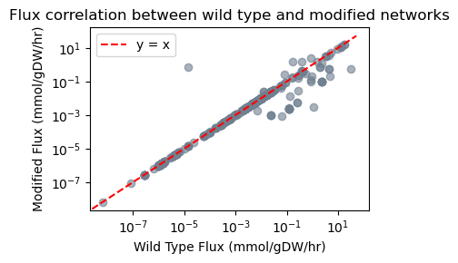

```python
plt.figure(figsize=(4, 3))
plt.scatter(df_common_fluxes["Flux_WildType"], df_common_fluxes["Flux_Modified"], alpha=0.6, color='slategrey')
plt.plot([df_common_fluxes["Flux_WildType"].min(), df_common_fluxes["Flux_WildType"].max()],
         [df_common_fluxes["Flux_WildType"].min(), df_common_fluxes["Flux_WildType"].max()],
         color='red', linestyle='--', label='y = x')
plt.xlabel("Wild Type Flux (mmol/gDW/hr)")
plt.xscale('log')
plt.yscale('log')
plt.ylabel("Modified Flux (mmol/gDW/hr)")
plt.title("Flux correlation between wild type and modified networks")
plt.legend()
plt.tight_layout()
plt.show()
```

When looking at the correlation between the fluxes of reactions in the wild-type network and in the network with addition of the 3HPP cycle, we see that most of the reactions have the same fluxes in both networks (dots are on the x=y line). However, some fluxes vary greatly between both networks. We can look at them in more details by focusing on the 20 reactions that have the highest different between both settings.

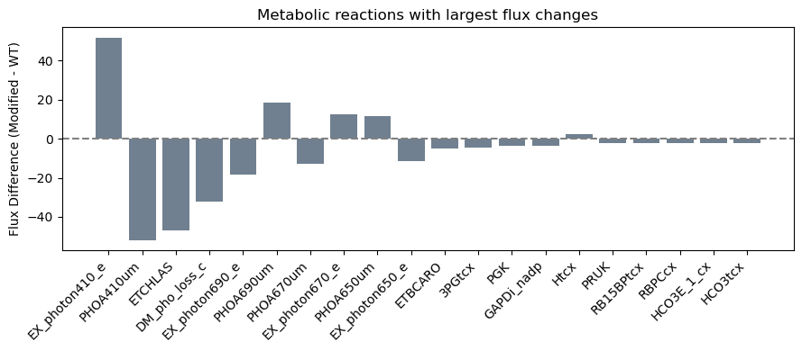

```python
# Sort by absolute flux difference and take top N
top_n = 20
df_top_changes = df_common_fluxes.reindex(df_common_fluxes["Flux_Difference"].abs().sort_values(ascending=False).index).head(top_n)

import matplotlib.pyplot as plt

plt.figure(figsize=(9, 4))
bars = plt.bar(df_top_changes["Reaction"], df_top_changes["Flux_Difference"], color='slategrey')
plt.axhline(0, color='gray', linestyle='--')
plt.xticks(rotation=45, ha='right')
plt.ylabel("Flux Difference (Modified - WT)")
plt.title('Metabolic reactions with largest flux changes')
plt.tight_layout()
plt.show()
```

## Testing the effects of gene deletion on the growth of the strain

We start from the model in which we added the 3HPP cycle.

```python
model_PCC7942_with_gene_deletion = model_PCC7942_with_gene_addition
```

We will delete the genes encoding:

- the alanine-glyoxylate aminotransferase (AGA) that would otherwise consume glyoxylate

- The carbonic anhydrase of carboxysome (caaA) to avoid the undesirable HCO3 -> CO2

reaction.

- the Rubisco to validate the project. Indeed, if cells live without the Rubisco but with the 3HP

cycle that means that the newly introduced cycle is able to perform HCO3 fixation and is able to fuel the whole cell metabolism.

First, we need to find the GPRs of all the reactions we intend to delete. GPRs indicate which genes encode the enzymes and whether they are redundant or synergistic.

```python
# Reactions of interest
reaction_ids = ['ENO', 'AGTi', 'PRUK', 'HCO3E_1_cx', 'RBPCcx']

genes_to_delete = set()

for rxn_id in reaction_ids:
    rxn = model_PCC7942_with_gene_deletion.reactions.get_by_id(rxn_id)
    # rxn.genes is a set of Gene objects linked to this reaction
    print(f"{rxn_id} GPR: {rxn.gene_reaction_rule}")
    for gene in rxn.genes:
        genes_to_delete.add(gene.id)

genes_to_delete = list(genes_to_delete)
```

```
ENO GPR: SYNPCC7942_RS03280
AGTi GPR: SYNPCC7942_RS10975
PRUK GPR: SYNPCC7942_RS05015
HCO3E_1_cx GPR: SYNPCC7942_RS07280 and SYNPCC7942_RS07405
RBPCcx GPR: SYNPCC7942_RS07295 and SYNPCC7942_RS07300 and SYNPCC7942_RS07280 and SYNPCC7942_RS07270 and SYNPCC7942_RS07275 and SYNPCC7942_RS01450 and SYNPCC7942_RS01445 and SYNPCC7942_RS07285 and SYNPCC7942_RS07290
```

### Strategy 1: Simulating an all-at-once deletion

To identify whether the growth of the strain is possible with the deletions, we can delete all at once and see if the cell can grow or not.

```python
model_all_deleted = model_PCC7942_with_gene_deletion.copy()
for gene_id in genes_to_delete:
    gene = model_all_deleted.genes.get_by_id(gene_id)
    gene.knock_out()
solution_all_deleted = model_all_deleted.optimize()
print("Growth after deleting all target genes:", solution_all_deleted.objective_value)
```

```
Growth after deleting all target genes: 2.0754273625109158e-17
```

After performing all deletions, the growth is null.

### Strategy 2: Try every possible combination of deletions (doesn't work yet, too long to run)

An alternative strategy is to test all possible number and combinations of deletions among the genes that have been targeted for deletion, to see if some particular combination do not impair the growth.

```python
from itertools import combinations
import pandas as pd

reaction_ids = ['ENO', 'AGTi', 'PRUK', 'HCO3E_1_cx', 'RBPCcx']

# Extract genes from reactions
genes_to_delete = set()
for rxn_id in reaction_ids:
    rxn = model_PCC7942_with_gene_deletion.reactions.get_by_id(rxn_id)
    for gene in rxn.genes:
        genes_to_delete.add(gene.id)

genes_to_delete = list(genes_to_delete)
print("Genes to delete:", genes_to_delete)

results = []

# Try all combinations of gene deletions (size 1 to all)
for r in range(1, len(genes_to_delete) + 1):
    for gene_combo in combinations(genes_to_delete, r):
        # Copy model fresh for each combo
        model_temp = model_PCC7942_with_gene_deletion.copy()

        # Knock out genes in this combo
        for gene_id in gene_combo:
            try:
                gene = model_temp.genes.get_by_id(gene_id)
                gene.knock_out()
            except KeyError:
                print(f"Gene {gene_id} not found in the model!")

        # Run FBA
        solution = model_temp.optimize()

        # Store results
        results.append({
            'Deleted_Genes': gene_combo,
            'Growth': solution.objective_value
        })

# Convert results to DataFrame for easy analysis
df_results = pd.DataFrame(results)

print(df_results)
```

```
Genes to delete: ['SYNPCC7942_RS07290', 'SYNPCC7942_RS10975', 'SYNPCC7942_RS07285', 'SYNPCC7942_RS01450', 'SYNPCC7942_RS07270', 'SYNPCC7942_RS05015', 'SYNPCC7942_RS07275', 'SYNPCC7942_RS03280', 'SYNPCC7942_RS07300', 'SYNPCC7942_RS07295', 'SYNPCC7942_RS07405', 'SYNPCC7942_RS01445', 'SYNPCC7942_RS0728…
```

[output not shown]

[output cut: 94 more lines]

[output not shown]

### Strategy 3: Deletion one by one

We can also deleted enzyme separately and independently and see whether one deletion in particular is lethal for the strain or not.

```python
reaction_ids = ['ENO', 'AGTi', 'PRUK', 'HCO3E_1_cx', 'RBPCcx']

results = []

for rxn_id in reaction_ids:
    # Copy the model fresh
    model_temp = model_PCC7942_with_gene_deletion.copy()

    rxn = model_temp.reactions.get_by_id(rxn_id)
    genes_to_delete = [gene.id for gene in rxn.genes]

    # Knock out all genes for this enzyme
    for gene_id in genes_to_delete:
        try:
            gene = model_temp.genes.get_by_id(gene_id)
            gene.knock_out()
        except KeyError:
            print(f"Gene {gene_id} not found in the model!")

    # Run FBA
    solution = model_temp.optimize()

    results.append({
        'Enzyme_Reaction': rxn_id,
        'Deleted_Genes': genes_to_delete,
        'Growth': solution.objective_value
    })

import pandas as pd
df_results = pd.DataFrame(results)

print(df_results)
```

```
  Enzyme_Reaction                                      Deleted_Genes  \
0             ENO                               [SYNPCC7942_RS03280]
1            AGTi                               [SYNPCC7942_RS10975]
2            PRUK                               [SYNPCC7942_RS05015]
3      HCO3E_1_cx           [SYNPCC7942_RS07280, SYNPCC7942_RS07405]
4          RBPCcx  [SYNPCC7942_RS07285, SYNPCC7942_RS01445, SYNPC...

         Growth
0  5.390251e-02
1  2.075427e-17
2  5.390251e-02
3  5.390251e-02
4  5.390251e-02
```

Deletion of AGTi seems to be lethal.

### Strategy 4: Deletion one by one but sequentially

Deleting enzymes one after the other.

```python
# Pick the gene you want to delete
gene_id = "SYNPCC7942_RS10975"
# Find all reactions associated with this gene
gene = model_ko.genes.get_by_id(gene_id)
print("Reactions associated with gene", gene_id, ":", [rxn.id for rxn in gene.reactions])
# Knock out each reaction associated with this gene
for rxn in gene.reactions:
    rxn.knock_out()

# Optimize the model
model_ko.objective = "BIOMASS__1"
solution = model_ko.optimize()

print("Growth after knocking out", gene_id, ":", solution.objective_value)
```

```
Reactions associated with gene SYNPCC7942_RS10975 : ['SPTc', 'AGTi', 'OHPBAT']
Growth after knocking out SYNPCC7942_RS10975 : 1.520547611407814e-17
```

```python
# Pick the gene you want to delete
gene_id = "SYNPCC7942_RS05015"
# Find all reactions associated with this gene
gene = model_PCC7942_with_gene_deletion.genes.get_by_id(gene_id)
print("Reactions associated with gene", gene_id, ":", [rxn.id for rxn in gene.reactions])
# Knock out each reaction associated with this gene
for rxn in gene.reactions:
    rxn.knock_out()
# Optimize the model
model_PCC7942_with_gene_deletion.objective = "BIOMASS__1"
solution = model_PCC7942_with_gene_deletion.optimize()
print("Growth after knocking out", gene_id, ":", solution.objective_value)
```

```
Reactions associated with gene SYNPCC7942_RS05015 : ['PRUK']
Growth after knocking out SYNPCC7942_RS05015 : 0.05390186774576593
```

```python
# Pick the gene you want to delete
gene_id = "SYNPCC7942_RS07280"

# Find all reactions associated with this gene
gene = model_ko.genes.get_by_id(gene_id)
print("Reactions associated with gene", gene_id, ":", [rxn.id for rxn in gene.reactions])

# Knock out each reaction associated with this gene
for rxn in gene.reactions:
    rxn.knock_out()

# Optimize the model
model_ko.objective = "BIOMASS__1"
solution = model_ko.optimize()

print("Growth after knocking out", gene_id, ":", solution.objective_value)
```

```
Reactions associated with gene SYNPCC7942_RS07280 : ['HCO3E_1_cx', 'RBPCcx']
Growth after knocking out SYNPCC7942_RS07280 : 0.0
```

```python
# Pick the gene you want to delete
gene_id = "SYNPCC7942_RS07405"

# Find all reactions associated with this gene
gene = model_ko.genes.get_by_id(gene_id)
print("Reactions associated with gene", gene_id, ":", [rxn.id for rxn in gene.reactions])

# Knock out each reaction associated with this gene
for rxn in gene.reactions:
    rxn.knock_out()

# Optimize the model
model_ko.objective = "BIOMASS__1"
solution = model_ko.optimize()

print("Growth after knocking out", gene_id, ":", solution.objective_value)
```

```
Reactions associated with gene SYNPCC7942_RS07405 : ['HCO3E_1_cx']
Growth after knocking out SYNPCC7942_RS07405 : 0.0
```

```python
# Pick the gene you want to delete
gene_id = "SYNPCC7942_RS07295"

# Find all reactions associated with this gene
gene = model_ko.genes.get_by_id(gene_id)
print("Reactions associated with gene", gene_id, ":", [rxn.id for rxn in gene.reactions])

# Knock out each reaction associated with this gene
for rxn in gene.reactions:
    rxn.knock_out()

# Optimize the model
model_ko.objective = "BIOMASS__1"
solution = model_ko.optimize()

print("Growth after knocking out", gene_id, ":", solution.objective_value)
```

```
Reactions associated with gene SYNPCC7942_RS07295 : ['RBPCcx']
Growth after knocking out SYNPCC7942_RS07295 : 0.0
```

```python
# Pick the gene you want to delete
gene_id = "SYNPCC7942_RS07300"

# Find all reactions associated with this gene
gene = model_ko.genes.get_by_id(gene_id)
print("Reactions associated with gene", gene_id, ":", [rxn.id for rxn in gene.reactions])

# Knock out each reaction associated with this gene
for rxn in gene.reactions:
    rxn.knock_out()

# Optimize the model
model_ko.objective = "BIOMASS__1"
solution = model_ko.optimize()

print("Growth after knocking out", gene_id, ":", solution.objective_value)
```

```
Reactions associated with gene SYNPCC7942_RS07300 : ['RBPCcx']
Growth after knocking out SYNPCC7942_RS07300 : 0.0
```

```python
# Pick the gene you want to delete
gene_id = "SYNPCC7942_RS07270"

# Find all reactions associated with this gene
gene = model_ko.genes.get_by_id(gene_id)
print("Reactions associated with gene", gene_id, ":", [rxn.id for rxn in gene.reactions])

# Knock out each reaction associated with this gene
for rxn in gene.reactions:
    rxn.knock_out()

# Optimize the model
model_ko.objective = "BIOMASS__1"
solution = model_ko.optimize()

print("Growth after knocking out", gene_id, ":", solution.objective_value)
```

```
Reactions associated with gene SYNPCC7942_RS07270 : ['RBPCcx']
Growth after knocking out SYNPCC7942_RS07270 : 0.0
```

```python
# Pick the gene you want to delete
gene_id = "SYNPCC7942_RS07275"

# Find all reactions associated with this gene
gene = model_ko.genes.get_by_id(gene_id)
print("Reactions associated with gene", gene_id, ":", [rxn.id for rxn in gene.reactions])

# Knock out each reaction associated with this gene
for rxn in gene.reactions:
    rxn.knock_out()

# Optimize the model
model_ko.objective = "BIOMASS__1"
solution = model_ko.optimize()

print("Growth after knocking out", gene_id, ":", solution.objective_value)
```

```
Reactions associated with gene SYNPCC7942_RS07275 : ['RBPCcx']
Growth after knocking out SYNPCC7942_RS07275 : 0.0
```

```python
# Pick the gene you want to delete
gene_id = "SYNPCC7942_RS01450"

# Find all reactions associated with this gene
gene = model_ko.genes.get_by_id(gene_id)
print("Reactions associated with gene", gene_id, ":", [rxn.id for rxn in gene.reactions])

# Knock out each reaction associated with this gene
for rxn in gene.reactions:
    rxn.knock_out()

# Optimize the model
model_ko.objective = "BIOMASS__1"
solution = model_ko.optimize()

print("Growth after knocking out", gene_id, ":", solution.objective_value)
```

```
Reactions associated with gene SYNPCC7942_RS01450 : ['RBPCcx']
Growth after knocking out SYNPCC7942_RS01450 : 0.0
```

```python
# Pick the gene you want to delete
gene_id = "SYNPCC7942_RS01445"

# Find all reactions associated with this gene
gene = model_ko.genes.get_by_id(gene_id)
print("Reactions associated with gene", gene_id, ":", [rxn.id for rxn in gene.reactions])

# Knock out each reaction associated with this gene
for rxn in gene.reactions:
    rxn.knock_out()

# Optimize the model
model_ko.objective = "BIOMASS__1"
solution = model_ko.optimize()

print("Growth after knocking out", gene_id, ":", solution.objective_value)
```

```
Reactions associated with gene SYNPCC7942_RS01445 : ['RBPCcx']
Growth after knocking out SYNPCC7942_RS01445 : 0.0
```

```python
# Pick the gene you want to delete
gene_id = "SYNPCC7942_RS07285"

# Find all reactions associated with this gene
gene = model_ko.genes.get_by_id(gene_id)
print("Reactions associated with gene", gene_id, ":", [rxn.id for rxn in gene.reactions])

# Knock out each reaction associated with this gene
for rxn in gene.reactions:
    rxn.knock_out()

# Optimize the model
model_ko.objective = "BIOMASS__1"
solution = model_ko.optimize()

print("Growth after knocking out", gene_id, ":", solution.objective_value)
```

```
Reactions associated with gene SYNPCC7942_RS07285 : ['RBPCcx']
Growth after knocking out SYNPCC7942_RS07285 : 0.0
```

```python
# Pick the gene you want to delete
gene_id = "SYNPCC7942_RS07290"

# Find all reactions associated with this gene
gene = model_ko.genes.get_by_id(gene_id)
print("Reactions associated with gene", gene_id, ":", [rxn.id for rxn in gene.reactions])

# Knock out each reaction associated with this gene
for rxn in gene.reactions:
    rxn.knock_out()

# Optimize the model
model_ko.objective = "BIOMASS__1"
solution = model_ko.optimize()

print("Growth after knocking out", gene_id, ":", solution.objective_value)
```

```
Reactions associated with gene SYNPCC7942_RS07290 : ['RBPCcx']
Growth after knocking out SYNPCC7942_RS07290 : 0.0
```

# References

[1] Broddrick JT, Rubin BE, Welkie DG, Du N, Mih N, Diamond S, Lee JJ, Golden SS, Palsson BO. Unique attributes of cyanobacterial metabolism revealed by improved genome-scale metabolic modeling and essential gene analysis. Proc Natl Acad Sci U S A. 2016 Dec 20;113(51):E8344-E8353. doi: 10.1073/pnas.1613446113. Epub 2016 Dec 1. PMID: 27911809; PMCID: PMC5187688.